# Лучшая страна для жизни в 2024 году

https://www.kaggle.com/datasets/rafsunahmad/best-country-to-live-in-2024

Лучшая страна для жизни в соответствии с отчетом по индексу человеческого развития

**О наборе данных** Этот набор данных содержит данные разных стран. Этот набор данных о лучшей стране для жизни в 2024 году. Этот набор данных лучше всего подходит для исследовательского анализа данных. Если вам нравится этот набор данных, пожалуйста, проголосуйте за него.

**population_2024** - Общая численность населения в 2024 году

**population_growthRate** - Темпы роста населения

**land_area** - Общая Площадь Страны

**country** - Название страны

**region** - Название региона

**unMember** - Является ли страна членом Организации Объединенных Наций или нет

**population_density** - Плотность Населения На КМ

**population_densityMi** - Плотность населения на милю

**share_borders** - Границы с другой страной

**Hdi2021** - Индекс человеческого развития, является метрикой, составленной Программой развития Организации Объединенных Наций и используемой для количественной оценки "средних достижений страны в трех основных измерениях развития человека: долгая и здоровая жизнь, знания и достойный уровень жизни.

**Hdi2020** - Индекс человеческого развития, является метрикой, составленной Программой развития Организации Объединенных Наций и используемой для количественной оценки "средних достижений страны в трех основных измерениях развития человека: долгая и здоровая жизнь, знания и достойный уровень жизни.

**WorldHappiness2022** - Индекс счастья

```python
import pandas as pd
import matplotlib.pyplot as plt
import plotly.express as px
```

```python
#Переменные

#переменая для head
a = 1000000

#переменая для размера ерафиков
b = 20
```

```python
# Загрузка CSV-файла в датафрейм
input_raw = pd.read_csv('2_Лучшая_страна_для_жизни_в_2024 году.csv')

# Отображение первых нескольких строк датафрейма, чтобы убедиться, что данные были успешно загружены
input_raw.head(a)
```

|  | population_2024 | population_growthRate | land_area | country | region | unMember | population_density | population_densityMi | share_borders | Hdi2021 | Hdi2020 | WorldHappiness2022 |
| --- | --- | --- | --- | --- | --- | --- | --- | --- | --- | --- | --- | --- |
| 0 | 1441719852 | 0.00916 | 3287590 | India | Asia | True | 484.9067 | 1255.9084 | AFG, BGD, BTN, MMR, CHN, NPL, PAK, LKA | 0.633 | 0.642 | 3.777 |
| 1 | 1425178782 | -0.00035 | 9706961 | China | Asia | True | 151.2174 | 391.6530 | AFG, BTN, MMR, HKG, IND, KAZ, PRK, KGZ, LAO, M... | 0.768 | 0.764 | 5.585 |
| 2 | 341814420 | 0.00535 | 9372610 | United States | North America | True | 37.3673 | 96.7813 | CAN, MEX | 0.921 | 0.920 | 6.977 |
| 3 | 279798049 | 0.00816 | 1904569 | Indonesia | Asia | True | 149.0254 | 385.9758 | TLS, MYS, PNG | 0.705 | 0.709 | 5.240 |
| 4 | 245209815 | 0.01964 | 881912 | Pakistan | Asia | True | 318.0908 | 823.8551 | AFG, CHN, IND, IRN | 0.544 | 0.543 | 4.516 |
| ... | ... | ... | ... | ... | ... | ... | ... | ... | ... | ... | ... | ... |
| 136 | 867605 | 0.01823 | 1862 | Comoros | Africa | True | 466.2037 | 1207.4675 | NaN | 0.558 | 0.562 | 4.609 |
| 137 | 661594 | 0.01043 | 2586 | Luxembourg | Europe | True | 256.9796 | 665.5772 | BEL, FRA, DEU | 0.930 | 0.924 | 7.404 |
| 138 | 626102 | -0.00061 | 13812 | Montenegro | Europe | True | 46.5503 | 120.5654 | ALB, BIH, HRV, KOS, SRB | 0.832 | 0.826 | 5.547 |
| 139 | 536740 | 0.00313 | 316 | Malta | Europe | True | 1677.3125 | 4344.2394 | NaN | 0.918 | 0.911 | 6.447 |
| 140 | 377689 | 0.00632 | 103000 | Iceland | Europe | True | 3.7458 | 9.7016 | NaN | 0.959 | 0.957 | 7.557 |

141 rows × 12 columns

```python
print(input_raw.dtypes)
```

```
population_2024            int64
population_growthRate    float64
land_area                  int64
country                   object
region                    object
unMember                    bool
population_density       float64
population_densityMi     float64
share_borders             object
Hdi2021                  float64
Hdi2020                  float64
WorldHappiness2022       float64
dtype: object
```

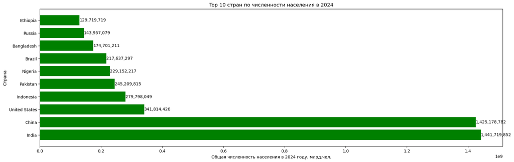

```python
input_raw_copy = input_raw.copy(deep = True)

# Сортировка DataFrame по столбцу 'population_2024' и выбор топ-10
top_countries = input_raw_copy.sort_values(by='population_2024', ascending=False).head(10)

# Размер графика
fig, ax = plt.subplots(figsize=(b, b * 0.3))

# Построение горизонтальной столбчатой диаграммы
bars = ax.barh(top_countries['country'], top_countries['population_2024'], color='green')

# Настройка осей и меток
ax.set_xlabel('Общая численность населения в 2024 году. млрд.чел.')
ax.set_ylabel('Страна')
ax.set_title('Top 10 стран по численности населения в 2024')

# Отображение значений над столбцами
for bar in bars:
    plt.text(bar.get_width(), bar.get_y() + bar.get_height() / 2,
             f'{bar.get_width():,.0f}',
             va='center', ha='left', color='black')

plt.show()
```

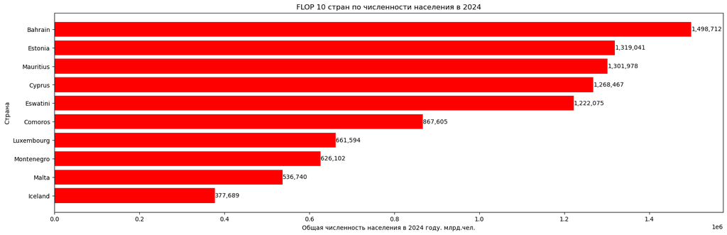

```python
input_raw_copy = input_raw.copy(deep = True)

# Сортировка DataFrame по столбцу 'population_2024' и выбор топ-10
top_countries = input_raw_copy.sort_values(by='population_2024', ascending=True).head(10)

# Размер графика
fig, ax = plt.subplots(figsize=(b, b * 0.3))

# Построение горизонтальной столбчатой диаграммы
bars = ax.barh(top_countries['country'], top_countries['population_2024'], color='red')

# Настройка осей и меток
ax.set_xlabel('Общая численность населения в 2024 году. млрд.чел.')
ax.set_ylabel('Страна')
ax.set_title('FLOP 10 стран по численности населения в 2024')

# Отображение значений над столбцами
for bar in bars:
    plt.text(bar.get_width(), bar.get_y() + bar.get_height() / 2,
             f'{bar.get_width():,.0f}',
             va='center', ha='left', color='black')

plt.show()
```

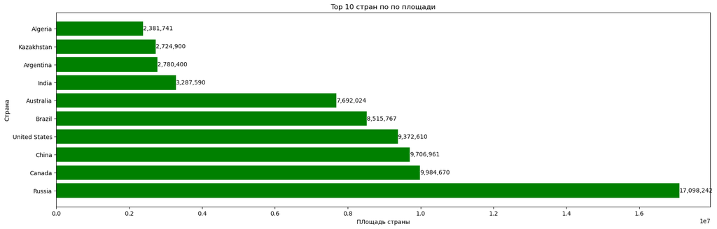

```python
input_raw_copy = input_raw.copy(deep = True)

# Сортировка DataFrame по столбцу 'population_2024' и выбор топ-10
top_countries = input_raw_copy.sort_values(by='land_area', ascending=False).head(10)

# Размер графика
fig, ax = plt.subplots(figsize=(b, b * 0.3))

# Построение горизонтальной столбчатой диаграммы
bars = ax.barh(top_countries['country'], top_countries['land_area'], color='green')

# Настройка осей и меток
ax.set_xlabel('ПЛощадь страны')
ax.set_ylabel('Страна')
ax.set_title('Top 10 стран по по площади')

# Отображение значений над столбцами
for bar in bars:
    plt.text(bar.get_width(), bar.get_y() + bar.get_height() / 2,
             f'{bar.get_width():,.0f}',
             va='center', ha='left', color='black')

plt.show()
```

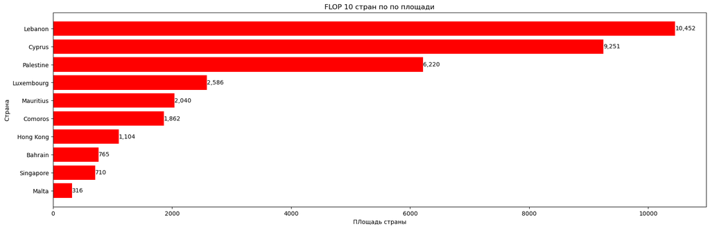

```python
input_raw_copy = input_raw.copy(deep = True)

# Сортировка DataFrame по столбцу 'population_2024' и выбор топ-10
top_countries = input_raw_copy.sort_values(by='land_area', ascending=True).head(10)

# Размер графика
fig, ax = plt.subplots(figsize=(b, b * 0.3))

# Построение горизонтальной столбчатой диаграммы
bars = ax.barh(top_countries['country'], top_countries['land_area'], color='red')

# Настройка осей и меток
ax.set_xlabel('ПЛощадь страны')
ax.set_ylabel('Страна')
ax.set_title('FLOP 10 стран по по площади')

# Отображение значений над столбцами
for bar in bars:
    plt.text(bar.get_width(), bar.get_y() + bar.get_height() / 2,
             f'{bar.get_width():,.0f}',
             va='center', ha='left', color='black')

plt.show()
```

Страны которые не входят в ООО

```python
input_raw_copy = input_raw.copy(deep = True)
# Фильтрация стран, не входящих в ООН
non_un_members = input_raw_copy[input_raw['unMember'] == False]

# Вывод результатов
non_un_members_table = non_un_members[[
    'population_2024',
    'population_growthRate',
    'land_area',
    'country',
    'region',
    'unMember',
    'population_density',
    'population_densityMi',
    'share_borders',
    'Hdi2021',
    'Hdi2020',
    'WorldHappiness2022'
]]

non_un_members_table
```

|  | population_2024 | population_growthRate | land_area | country | region | unMember | population_density | population_densityMi | share_borders | Hdi2021 | Hdi2020 | WorldHappiness2022 |
| --- | --- | --- | --- | --- | --- | --- | --- | --- | --- | --- | --- | --- |
| 89 | 7496681 | 0.00068 | 1104 | Hong Kong | Asia | False | 7139.6962 | 18491.8131 | CHN | 0.952 | 0.949 | 5.425 |

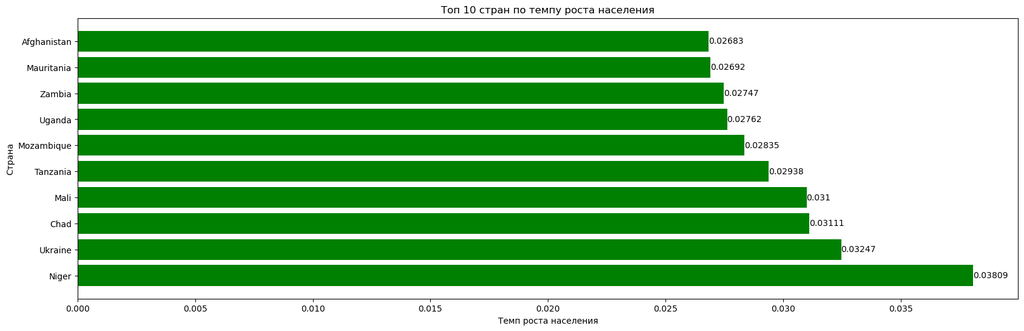

```python
# Создайте копию датафрейма
input_raw_copy = input_raw.copy(deep=True)

# Отсортируйте датафрейм по столбцу population_growthRate и возьмите топ 10
top_10_countries = input_raw_copy.sort_values(by='population_growthRate', ascending=False).head(10)

# Создайте горизонтальную столбчатую диаграмму
fig, ax = plt.subplots(figsize=(b, b * 0.3))
bars = ax.barh(top_10_countries['country'], top_10_countries['population_growthRate'], color='green')

# Настройте подписи осей и заголовок
ax.set_xlabel('Темп роста населения')
ax.set_ylabel('Страна')
ax.set_title('Топ 10 стран по темпу роста населения')

# Добавьте значения на график
for bar in bars:
    yval = bar.get_width()  # Используйте get_width() вместо get_height()
    plt.text(yval, bar.get_y() + bar.get_height()/2, round(yval, 5), ha='left', va='center', color='black')

# Отобразите график
plt.show()
```

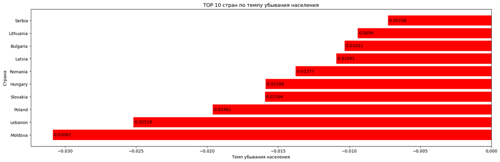

```python
# Создайте копию датафрейма
input_raw_copy = input_raw.copy(deep=True)

# Отсортируйте датафрейм по столбцу population_growthRate и возьмите топ 10
top_10_countries = input_raw_copy.sort_values(by='population_growthRate', ascending=True).head(10)

# Создайте горизонтальную столбчатую диаграмму
fig, ax = plt.subplots(figsize=(b, b * 0.3))
bars = ax.barh(top_10_countries['country'], top_10_countries['population_growthRate'], color='red')

# Настройте подписи осей и заголовок
ax.set_xlabel('Темп убывания населения')
ax.set_ylabel('Страна')
ax.set_title('TOP 10 стран по темпу убывания населения')

# Добавьте значения на график
for bar in bars:
    yval = bar.get_width()  # Используйте get_width() вместо get_height()
    plt.text(yval, bar.get_y() + bar.get_height()/2, round(yval, 5), ha='left', va='center', color='black')

# Отобразите график
plt.show()
```

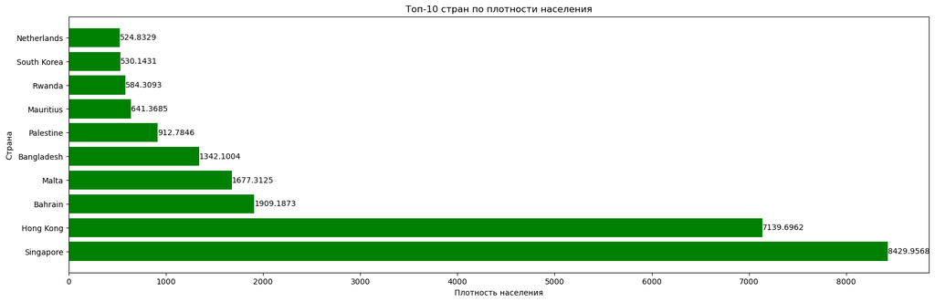

```python
input_raw_copy = input_raw.copy(deep = True)

# Сортировка по плотности населения и выбор топ-10 стран
top_10_countries = input_raw.sort_values(by='population_density', ascending=False).head(10)

# Создание графика
fig, ax = plt.subplots(figsize=(b, b * 0.3))

# Построение горизонтальной столбчатой диаграммы
bars = ax.barh(top_10_countries['country'], top_10_countries['population_density'], color='green')

# Настройка осей и заголовка
ax.set_xlabel('Плотность населения')
ax.set_ylabel('Страна')
ax.set_title('Топ-10 стран по плотности населения')

# Добавление значения над каждым столбцом
# Добавьте значения на график
for bar in bars:
    yval = bar.get_width()  # Используйте get_width() вместо get_height()
    plt.text(yval, bar.get_y() + bar.get_height()/2, round(yval, 5), ha='left', va='center', color='black')

# Отображение графика
plt.show()
```

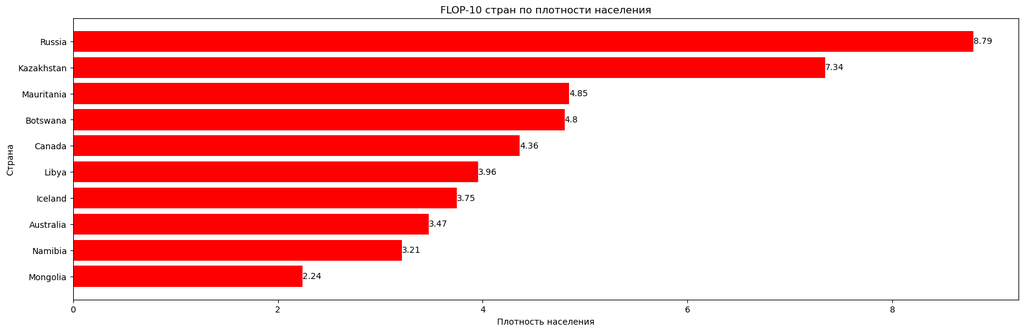

```python
input_raw_copy = input_raw.copy(deep = True)

# Сортировка по плотности населения и выбор топ-10 стран
top_10_countries = input_raw.sort_values(by='population_density', ascending=True).head(10)

# Создание графика
fig, ax = plt.subplots(figsize=(b, b * 0.3))

# Построение горизонтальной столбчатой диаграммы
bars = ax.barh(top_10_countries['country'], top_10_countries['population_density'], color='red')

# Настройка осей и заголовка
ax.set_xlabel('Плотность населения')
ax.set_ylabel('Страна')
ax.set_title('FLOP-10 стран по плотности населения')

# Добавление значения над каждым столбцом
for bar in bars:
    yval = bar.get_width()
    plt.text(yval, bar.get_y() + bar.get_height()/2, round(yval, 2), va='center', ha='left', color='black')

# Отображение графика
plt.show()
```

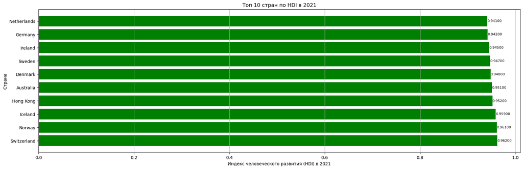

```python
input_raw_copy = input_raw.copy(deep = True)


# Сортировка датафрейма по столбцу Hdi2021 и выбор топ 10
top_countries = input_raw_copy.sort_values(by='Hdi2021', ascending=False).head(10)

# Создание горизонтальной столбчатой диаграммы
plt.figure(figsize=(b, b * 0.3))
bars = plt.barh(top_countries['country'], top_countries['Hdi2021'], color='green')
plt.xlabel('Индекс человеческого развития (HDI) в 2021')
plt.ylabel('Страна')
plt.title('Топ 10 стран по HDI в 2021')
plt.grid(axis='x')

# Добавление значений на график
for bar, value in zip(bars, top_countries['Hdi2021']):
    plt.text(bar.get_width(), bar.get_y() + bar.get_height() / 2, f'{value:.5f}',
             va='center', ha='left', fontsize=8, color='black')

# Показать график
plt.show()
```

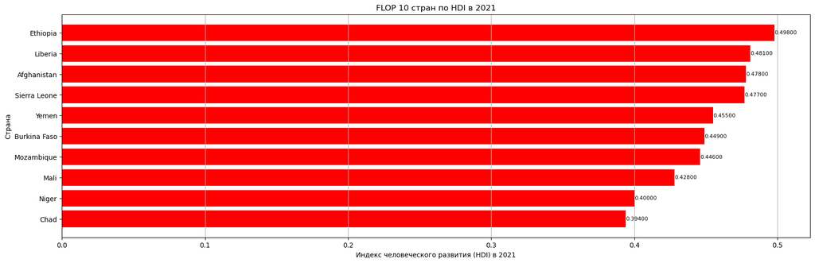

```python
input_raw_copy = input_raw.copy(deep = True)

# Сортировка датафрейма по столбцу Hdi2021 и выбор топ 10
top_countries = input_raw_copy.sort_values(by='Hdi2021', ascending=True).head(10)

# Создание горизонтальной столбчатой диаграммы
plt.figure(figsize=(b, b * 0.3))  # Размер графика (8, 2.4), замените на ваш b и b * 0.3
bars = plt.barh(top_countries['country'], top_countries['Hdi2021'], color='red')
plt.xlabel('Индекс человеческого развития (HDI) в 2021')
plt.ylabel('Страна')
plt.title('FLOP 10 стран по HDI в 2021')
plt.grid(axis='x')

# Добавление значений на график
for bar, value in zip(bars, top_countries['Hdi2021']):
    plt.text(bar.get_width(), bar.get_y() + bar.get_height() / 2, f'{value:.5f}',
             va='center', ha='left', fontsize=8, color='black')

# Показать график
plt.show()
```

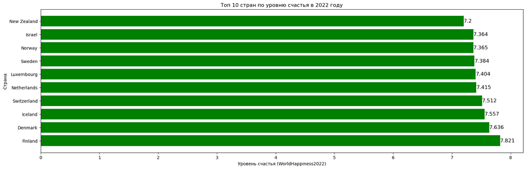

```python
input_raw_copy = input_raw.copy(deep = True)

# Сортировка по столбцу WorldHappiness2022 и выбор топ 10
top_countries = input_raw_copy.sort_values(by='WorldHappiness2022', ascending=False).head(10)

# Установка размеров графика
b = 10  # Ширина графика
fig, ax = plt.subplots(figsize=(b *2, b * 0.6))

# Построение горизонтальной столбчатой диаграммы
bars = ax.barh(top_countries['country'], top_countries['WorldHappiness2022'], color='green')

# Настройка осей и заголовка
ax.set_xlabel('Уровень счастья (WorldHappiness2022)')
ax.set_ylabel('Страна')
ax.set_title('Топ 10 стран по уровню счастья в 2022 году')

# Добавление значения на каждом столбце
for bar in bars:
    xval = bar.get_width()
    ax.text(xval, bar.get_y() + bar.get_height()/2, round(xval, 5), va='center', ha='left', fontsize=12)

# Отображение графика
plt.show()
```

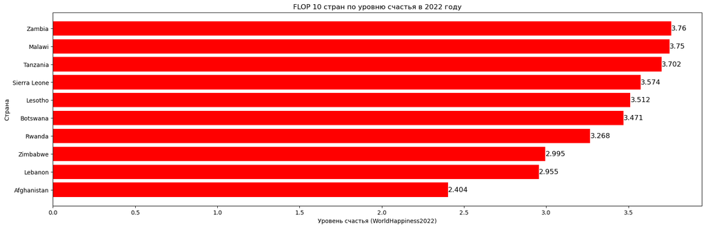

```python
input_raw_copy = input_raw.copy(deep = True)

# Сортировка по столбцу WorldHappiness2022 и выбор топ 10
top_countries = input_raw_copy.sort_values(by='WorldHappiness2022', ascending=True).head(10)

# Установка размеров графика
b = 10  # Ширина графика
fig, ax = plt.subplots(figsize=(b *2, b * 0.6))

# Построение горизонтальной столбчатой диаграммы
bars = ax.barh(top_countries['country'], top_countries['WorldHappiness2022'], color='red')

# Настройка осей и заголовка
ax.set_xlabel('Уровень счастья (WorldHappiness2022)')
ax.set_ylabel('Страна')
ax.set_title('FLOP 10 стран по уровню счастья в 2022 году')

# Добавление значения на каждом столбце
for bar in bars:
    xval = bar.get_width()
    ax.text(xval, bar.get_y() + bar.get_height()/2, round(xval, 5), va='center', ha='left', fontsize=12)

# Отображение графика
plt.show()
```

```python
input_raw_copy = input_raw.copy(deep = True)

fig = px.choropleth(
    input_raw_copy,
    locations="country",
    locationmode="country names",
    color="WorldHappiness2022",
    hover_name="country",
    title="World Happiness 2022",
    color_continuous_scale="RdYlGn",  # Выберите нужную цветовую схему
    projection="natural earth"
)

fig.update_layout(
    height=600,  # Указываете желаемую высоту графика
    width=1000    # Указываете желаемую ширину графика
)

fig.show()
```

[interactive chart not shown]